# index

1 Bスプライン関数での回帰

1.1 Bスプライン関数の描画

1.2 B-spline関数による回帰

1.3 B-spline回帰に対する結果と考察

2 回帰分析の実験

3 推定結果についての考察

4 平滑化パラメータへの依存性

4.1 テストデータを用いた実験

4.2 考察

# Bスプライン関数での回帰

## Bスプライン関数の描画

$0$次のB-spline関数については $$ b_j(x;0)=\begin{cases} 1 & x\in [t_j,t_{j+1}]\\ 0 & x \notin [t_j,t_{j+1}] \end{cases} ,\quad j=1,2,\ldots,m $$ で定められる。$r\geq 1$次については以下の漸化式により求める。

$$ b_j(x;r)=\frac{x-t_j}{t_{j+r}-t_i}b_{j}(x;r-1)+\frac{t_{j+r+1}-x}{t_{j+r+1}-t_{j+1}}b_{j+1}(x;r-1) $$

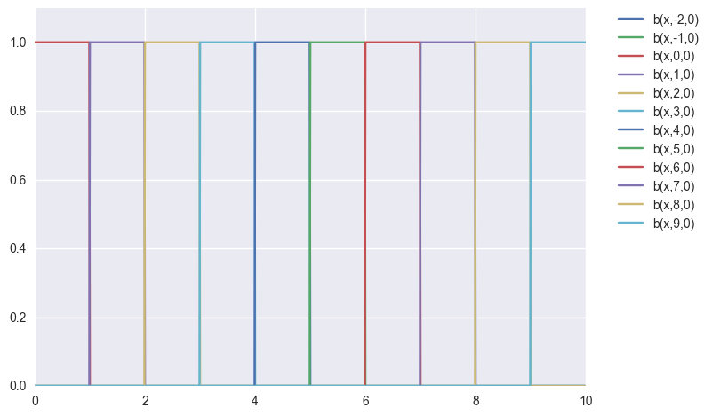

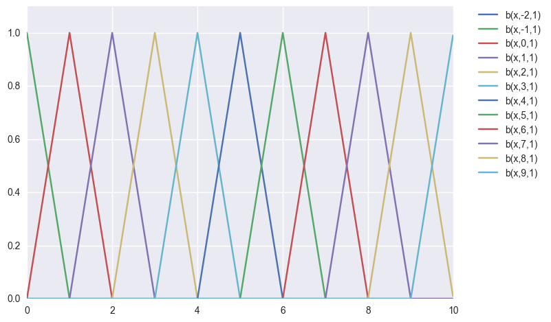

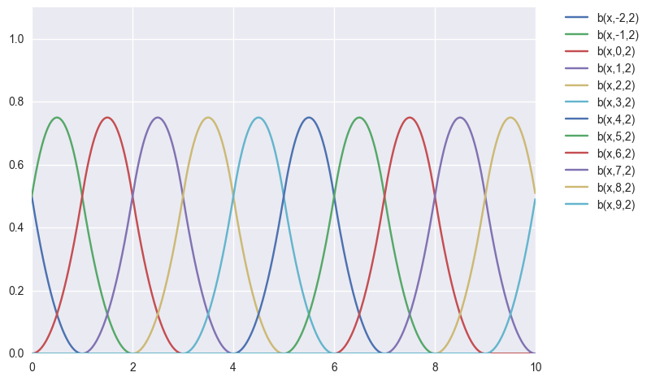

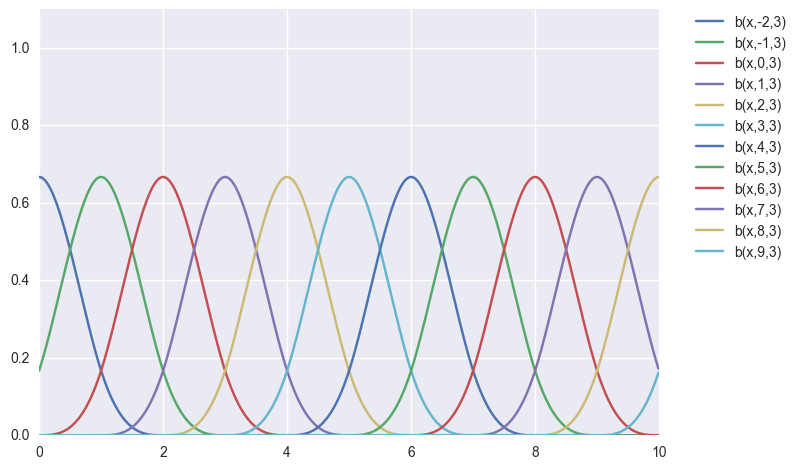

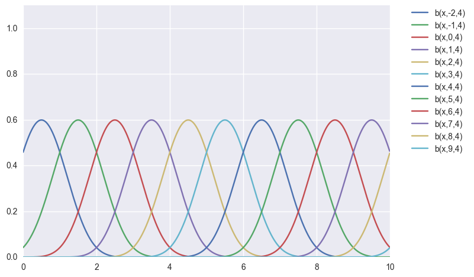

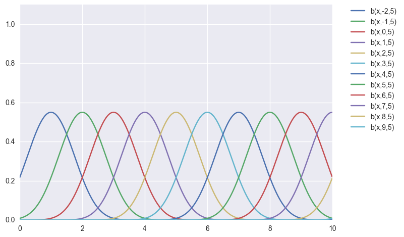

```python
%matplotlib inline
import numpy as np
import matplotlib.pyplot as plt
import seaborn as sns

def b(x,j,r,h):
    if r==0:
        if x >= j*h and x < (j+1)*h:
            return 1
        else:
            return 0
    else:
        return (x-j*h)/((j+r)*h-j*h)*b(x,j,r-1,h)+((j+r+1)*h-x)/((j+r+1)*h-(j+1)*h)*b(x,j+1,r-1,h)

x=np.arange(0,10,0.01)

for r in range(6):
    for j in range(-2,10):
        y=[b(x_val,j,r,1) for x_val in x]
        plt.hold(True)
        plt.plot(x,y,label="b(x,%d,%d)" % (j,r))
        plt.legend(bbox_to_anchor=(1.05, 1), loc='upper left', borderaxespad=0)
    plt.ylim(0,1.1)
    plt.show()
```

## B-spline関数による回帰

YAHOOの株価のデータをpandasのdatareaderを用いて取り出し、3次B-spline関数による回帰を行なってみる。

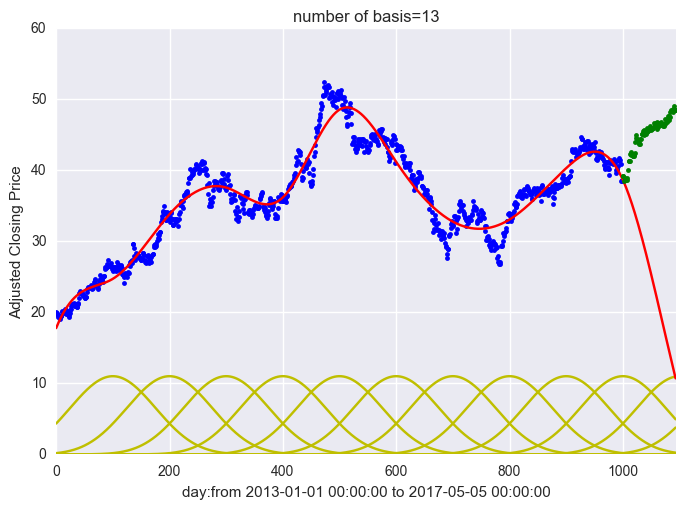

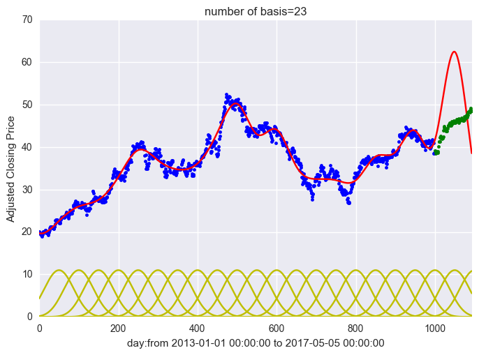

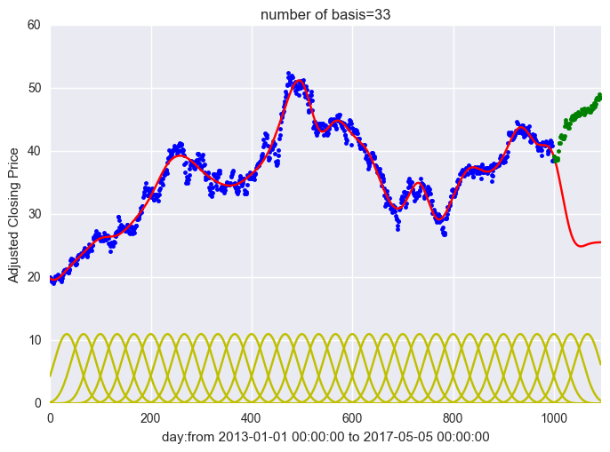

```python
import pandas_datareader.data as web
import datetime

start = datetime.datetime(2013, 1, 1)
end = datetime.datetime(2017, 5, 5)
d=web.DataReader("YHOO","yahoo",start,end)#訓練用データ
n_data=len(d) #全データ数
n=1000 #訓練データ数

xlist=np.arange(0,n,1)
ylist=list(d["Adj Close"][:n]) #Adj Closeは調整後の株価の終値：目的変数

x_test=np.arange(n,n_data,1)
y_test=list(d["Adj Close"][n:n_data])

def Base(x,m):
    BB=list(b(x,j,3,h) for j in range(-2,m))
    return np.append(1,BB)

for m in [10,20,30]:
    h=n/m
    B = np.array([Base(x,m) for x in xlist])
    w = np.linalg.solve(np.dot(B.T, B), np.dot(B.T,ylist))

    x_ac=np.arange(0,n_data,1)

    y_est = [np.dot(w, Base(x,m)) for x in x_ac]

    for j in range(-2,m):
        y=[20*b(x,j,r,h) for x in x_ac]
        plt.plot(x_ac,y,"y-")
    plt.plot(xlist,ylist, 'b.')
    plt.plot(x_ac,y_est,"r-")
    plt.plot(x_test,y_test,"g.")
    plt.xlim(0,n_data)
    plt.xlabel("day:from %s to %s" % (start,end))
    plt.ylabel("Adjusted Closing Price")
    plt.title("number of basis=%d" % (m+3))
    plt.show()
```

## B-spline回帰に対する結果と考察

定数関数と合わせて$13,23,33$個で回帰を行なった。回帰はそこそこに行えていることがわかる。 予測に関しては見事に失敗している。

# 回帰分析の実験

ボストンの住宅価格データhttps://archive.ics.uci.edu/ml/datasets/Housing に対して重回帰を行った。

```python
import pandas as pd
import numpy as np
from sklearn import linear_model as lm

index=pd.DataFrame(["犯罪率","宅地の割合","非商用地の割合","チャールズ流域かどうか",
                    "窒素酸化物濃度","平均部屋数","築年数",
                    "ビジネス地区への距離","高速道路へのアクセス指数",
                    "固定資産税","学生と教師の割合","黒人の割合","低所得者の割合"],
      index=["crim","zn","indus","chas","nox","rm","age","dis","rad","tax","ptratio","black","lstat"],
      columns=["説明変数の意味"]
           )
index
```

|  | 説明変数の意味 |
| --- | --- |
| crim | 犯罪率 |
| zn | 宅地の割合 |
| indus | 非商用地の割合 |
| chas | チャールズ流域かどうか |
| nox | 窒素酸化物濃度 |
| rm | 平均部屋数 |
| age | 築年数 |
| dis | ビジネス地区への距離 |
| rad | 高速道路へのアクセス指数 |
| tax | 固定資産税 |
| ptratio | 学生と教師の割合 |
| black | 黒人の割合 |
| lstat | 低所得者の割合 |

```python
df = pd.read_csv("Boston.csv", index_col=0)

df
```

|  | crim | zn | indus | chas | nox | rm | age | dis | rad | tax | ptratio | black | lstat | medv |
| --- | --- | --- | --- | --- | --- | --- | --- | --- | --- | --- | --- | --- | --- | --- |
| 1 | 0.00632 | 18.0 | 2.31 | 0 | 0.538 | 6.575 | 65.2 | 4.0900 | 1 | 296 | 15.3 | 396.90 | 4.98 | 24.0 |
| 2 | 0.02731 | 0.0 | 7.07 | 0 | 0.469 | 6.421 | 78.9 | 4.9671 | 2 | 242 | 17.8 | 396.90 | 9.14 | 21.6 |
| 3 | 0.02729 | 0.0 | 7.07 | 0 | 0.469 | 7.185 | 61.1 | 4.9671 | 2 | 242 | 17.8 | 392.83 | 4.03 | 34.7 |
| 4 | 0.03237 | 0.0 | 2.18 | 0 | 0.458 | 6.998 | 45.8 | 6.0622 | 3 | 222 | 18.7 | 394.63 | 2.94 | 33.4 |
| 5 | 0.06905 | 0.0 | 2.18 | 0 | 0.458 | 7.147 | 54.2 | 6.0622 | 3 | 222 | 18.7 | 396.90 | 5.33 | 36.2 |
| 6 | 0.02985 | 0.0 | 2.18 | 0 | 0.458 | 6.430 | 58.7 | 6.0622 | 3 | 222 | 18.7 | 394.12 | 5.21 | 28.7 |
| 7 | 0.08829 | 12.5 | 7.87 | 0 | 0.524 | 6.012 | 66.6 | 5.5605 | 5 | 311 | 15.2 | 395.60 | 12.43 | 22.9 |
| 8 | 0.14455 | 12.5 | 7.87 | 0 | 0.524 | 6.172 | 96.1 | 5.9505 | 5 | 311 | 15.2 | 396.90 | 19.15 | 27.1 |
| 9 | 0.21124 | 12.5 | 7.87 | 0 | 0.524 | 5.631 | 100.0 | 6.0821 | 5 | 311 | 15.2 | 386.63 | 29.93 | 16.5 |
| 10 | 0.17004 | 12.5 | 7.87 | 0 | 0.524 | 6.004 | 85.9 | 6.5921 | 5 | 311 | 15.2 | 386.71 | 17.10 | 18.9 |
| 11 | 0.22489 | 12.5 | 7.87 | 0 | 0.524 | 6.377 | 94.3 | 6.3467 | 5 | 311 | 15.2 | 392.52 | 20.45 | 15.0 |
| 12 | 0.11747 | 12.5 | 7.87 | 0 | 0.524 | 6.009 | 82.9 | 6.2267 | 5 | 311 | 15.2 | 396.90 | 13.27 | 18.9 |
| 13 | 0.09378 | 12.5 | 7.87 | 0 | 0.524 | 5.889 | 39.0 | 5.4509 | 5 | 311 | 15.2 | 390.50 | 15.71 | 21.7 |
| 14 | 0.62976 | 0.0 | 8.14 | 0 | 0.538 | 5.949 | 61.8 | 4.7075 | 4 | 307 | 21.0 | 396.90 | 8.26 | 20.4 |
| 15 | 0.63796 | 0.0 | 8.14 | 0 | 0.538 | 6.096 | 84.5 | 4.4619 | 4 | 307 | 21.0 | 380.02 | 10.26 | 18.2 |
| 16 | 0.62739 | 0.0 | 8.14 | 0 | 0.538 | 5.834 | 56.5 | 4.4986 | 4 | 307 | 21.0 | 395.62 | 8.47 | 19.9 |
| 17 | 1.05393 | 0.0 | 8.14 | 0 | 0.538 | 5.935 | 29.3 | 4.4986 | 4 | 307 | 21.0 | 386.85 | 6.58 | 23.1 |
| 18 | 0.78420 | 0.0 | 8.14 | 0 | 0.538 | 5.990 | 81.7 | 4.2579 | 4 | 307 | 21.0 | 386.75 | 14.67 | 17.5 |
| 19 | 0.80271 | 0.0 | 8.14 | 0 | 0.538 | 5.456 | 36.6 | 3.7965 | 4 | 307 | 21.0 | 288.99 | 11.69 | 20.2 |
| 20 | 0.72580 | 0.0 | 8.14 | 0 | 0.538 | 5.727 | 69.5 | 3.7965 | 4 | 307 | 21.0 | 390.95 | 11.28 | 18.2 |
| 21 | 1.25179 | 0.0 | 8.14 | 0 | 0.538 | 5.570 | 98.1 | 3.7979 | 4 | 307 | 21.0 | 376.57 | 21.02 | 13.6 |
| 22 | 0.85204 | 0.0 | 8.14 | 0 | 0.538 | 5.965 | 89.2 | 4.0123 | 4 | 307 | 21.0 | 392.53 | 13.83 | 19.6 |
| 23 | 1.23247 | 0.0 | 8.14 | 0 | 0.538 | 6.142 | 91.7 | 3.9769 | 4 | 307 | 21.0 | 396.90 | 18.72 | 15.2 |
| 24 | 0.98843 | 0.0 | 8.14 | 0 | 0.538 | 5.813 | 100.0 | 4.0952 | 4 | 307 | 21.0 | 394.54 | 19.88 | 14.5 |
| 25 | 0.75026 | 0.0 | 8.14 | 0 | 0.538 | 5.924 | 94.1 | 4.3996 | 4 | 307 | 21.0 | 394.33 | 16.30 | 15.6 |
| 26 | 0.84054 | 0.0 | 8.14 | 0 | 0.538 | 5.599 | 85.7 | 4.4546 | 4 | 307 | 21.0 | 303.42 | 16.51 | 13.9 |
| 27 | 0.67191 | 0.0 | 8.14 | 0 | 0.538 | 5.813 | 90.3 | 4.6820 | 4 | 307 | 21.0 | 376.88 | 14.81 | 16.6 |
| 28 | 0.95577 | 0.0 | 8.14 | 0 | 0.538 | 6.047 | 88.8 | 4.4534 | 4 | 307 | 21.0 | 306.38 | 17.28 | 14.8 |
| 29 | 0.77299 | 0.0 | 8.14 | 0 | 0.538 | 6.495 | 94.4 | 4.4547 | 4 | 307 | 21.0 | 387.94 | 12.80 | 18.4 |
| 30 | 1.00245 | 0.0 | 8.14 | 0 | 0.538 | 6.674 | 87.3 | 4.2390 | 4 | 307 | 21.0 | 380.23 | 11.98 | 21.0 |
| ... | ... | ... | ... | ... | ... | ... | ... | ... | ... | ... | ... | ... | ... | ... |
| 477 | 4.87141 | 0.0 | 18.10 | 0 | 0.614 | 6.484 | 93.6 | 2.3053 | 24 | 666 | 20.2 | 396.21 | 18.68 | 16.7 |
| 478 | 15.02340 | 0.0 | 18.10 | 0 | 0.614 | 5.304 | 97.3 | 2.1007 | 24 | 666 | 20.2 | 349.48 | 24.91 | 12.0 |
| 479 | 10.23300 | 0.0 | 18.10 | 0 | 0.614 | 6.185 | 96.7 | 2.1705 | 24 | 666 | 20.2 | 379.70 | 18.03 | 14.6 |
| 480 | 14.33370 | 0.0 | 18.10 | 0 | 0.614 | 6.229 | 88.0 | 1.9512 | 24 | 666 | 20.2 | 383.32 | 13.11 | 21.4 |
| 481 | 5.82401 | 0.0 | 18.10 | 0 | 0.532 | 6.242 | 64.7 | 3.4242 | 24 | 666 | 20.2 | 396.90 | 10.74 | 23.0 |
| 482 | 5.70818 | 0.0 | 18.10 | 0 | 0.532 | 6.750 | 74.9 | 3.3317 | 24 | 666 | 20.2 | 393.07 | 7.74 | 23.7 |
| 483 | 5.73116 | 0.0 | 18.10 | 0 | 0.532 | 7.061 | 77.0 | 3.4106 | 24 | 666 | 20.2 | 395.28 | 7.01 | 25.0 |
| 484 | 2.81838 | 0.0 | 18.10 | 0 | 0.532 | 5.762 | 40.3 | 4.0983 | 24 | 666 | 20.2 | 392.92 | 10.42 | 21.8 |
| 485 | 2.37857 | 0.0 | 18.10 | 0 | 0.583 | 5.871 | 41.9 | 3.7240 | 24 | 666 | 20.2 | 370.73 | 13.34 | 20.6 |
| 486 | 3.67367 | 0.0 | 18.10 | 0 | 0.583 | 6.312 | 51.9 | 3.9917 | 24 | 666 | 20.2 | 388.62 | 10.58 | 21.2 |
| 487 | 5.69175 | 0.0 | 18.10 | 0 | 0.583 | 6.114 | 79.8 | 3.5459 | 24 | 666 | 20.2 | 392.68 | 14.98 | 19.1 |
| 488 | 4.83567 | 0.0 | 18.10 | 0 | 0.583 | 5.905 | 53.2 | 3.1523 | 24 | 666 | 20.2 | 388.22 | 11.45 | 20.6 |
| 489 | 0.15086 | 0.0 | 27.74 | 0 | 0.609 | 5.454 | 92.7 | 1.8209 | 4 | 711 | 20.1 | 395.09 | 18.06 | 15.2 |
| 490 | 0.18337 | 0.0 | 27.74 | 0 | 0.609 | 5.414 | 98.3 | 1.7554 | 4 | 711 | 20.1 | 344.05 | 23.97 | 7.0 |
| 491 | 0.20746 | 0.0 | 27.74 | 0 | 0.609 | 5.093 | 98.0 | 1.8226 | 4 | 711 | 20.1 | 318.43 | 29.68 | 8.1 |
| 492 | 0.10574 | 0.0 | 27.74 | 0 | 0.609 | 5.983 | 98.8 | 1.8681 | 4 | 711 | 20.1 | 390.11 | 18.07 | 13.6 |
| 493 | 0.11132 | 0.0 | 27.74 | 0 | 0.609 | 5.983 | 83.5 | 2.1099 | 4 | 711 | 20.1 | 396.90 | 13.35 | 20.1 |
| 494 | 0.17331 | 0.0 | 9.69 | 0 | 0.585 | 5.707 | 54.0 | 2.3817 | 6 | 391 | 19.2 | 396.90 | 12.01 | 21.8 |
| 495 | 0.27957 | 0.0 | 9.69 | 0 | 0.585 | 5.926 | 42.6 | 2.3817 | 6 | 391 | 19.2 | 396.90 | 13.59 | 24.5 |
| 496 | 0.17899 | 0.0 | 9.69 | 0 | 0.585 | 5.670 | 28.8 | 2.7986 | 6 | 391 | 19.2 | 393.29 | 17.60 | 23.1 |
| 497 | 0.28960 | 0.0 | 9.69 | 0 | 0.585 | 5.390 | 72.9 | 2.7986 | 6 | 391 | 19.2 | 396.90 | 21.14 | 19.7 |
| 498 | 0.26838 | 0.0 | 9.69 | 0 | 0.585 | 5.794 | 70.6 | 2.8927 | 6 | 391 | 19.2 | 396.90 | 14.10 | 18.3 |
| 499 | 0.23912 | 0.0 | 9.69 | 0 | 0.585 | 6.019 | 65.3 | 2.4091 | 6 | 391 | 19.2 | 396.90 | 12.92 | 21.2 |
| 500 | 0.17783 | 0.0 | 9.69 | 0 | 0.585 | 5.569 | 73.5 | 2.3999 | 6 | 391 | 19.2 | 395.77 | 15.10 | 17.5 |
| 501 | 0.22438 | 0.0 | 9.69 | 0 | 0.585 | 6.027 | 79.7 | 2.4982 | 6 | 391 | 19.2 | 396.90 | 14.33 | 16.8 |
| 502 | 0.06263 | 0.0 | 11.93 | 0 | 0.573 | 6.593 | 69.1 | 2.4786 | 1 | 273 | 21.0 | 391.99 | 9.67 | 22.4 |
| 503 | 0.04527 | 0.0 | 11.93 | 0 | 0.573 | 6.120 | 76.7 | 2.2875 | 1 | 273 | 21.0 | 396.90 | 9.08 | 20.6 |
| 504 | 0.06076 | 0.0 | 11.93 | 0 | 0.573 | 6.976 | 91.0 | 2.1675 | 1 | 273 | 21.0 | 396.90 | 5.64 | 23.9 |
| 505 | 0.10959 | 0.0 | 11.93 | 0 | 0.573 | 6.794 | 89.3 | 2.3889 | 1 | 273 | 21.0 | 393.45 | 6.48 | 22.0 |
| 506 | 0.04741 | 0.0 | 11.93 | 0 | 0.573 | 6.030 | 80.8 | 2.5050 | 1 | 273 | 21.0 | 396.90 | 7.88 | 11.9 |

506 rows × 14 columns

medvが住宅価格の中央値である。これを目的変数とする。

```python
y_tr = df.iloc[:400,  13].values #目的変数
y_test = df.iloc[400:,13].values

df = (df - df.mean())/df.std() #基準化

X_tr = df.iloc[:400, :13].values #説明変数の行列
X_test = df.iloc[400:,:13].values


linear=lm.LinearRegression()
lasso = lm.Lasso(alpha=0.1)
ridge = lm.Ridge(alpha=0.1)

linear.fit(X_tr,y_tr)
ridge.fit(X_tr,y_tr)
lasso.fit(X_tr,y_tr)

result_coef = pd.DataFrame([linear.coef_,ridge.coef_,lasso.coef_],index = ["Linear","Ridge","Lasso"], columns=list(df.columns.values)[0:13])
result_coef
```

|  | crim | zn | indus | chas | nox | rm | age | dis | rad | tax | ptratio | black | lstat |
| --- | --- | --- | --- | --- | --- | --- | --- | --- | --- | --- | --- | --- | --- |
| Linear | -1.645014 | 1.031529 | 0.378834 | 0.435933 | -1.737669 | 3.434203 | 0.073446 | -2.726490 | 4.221168 | -2.595584 | -1.750997 | -0.117981 | -3.698740 |
| Ridge | -1.641838 | 1.029904 | 0.375149 | 0.436795 | -1.734277 | 3.434718 | 0.072555 | -2.724546 | 4.204794 | -2.582164 | -1.749829 | -0.115637 | -3.697582 |
| Lasso | -1.115042 | 0.718112 | -0.000000 | 0.457342 | -1.178239 | 3.549197 | -0.000000 | -2.257989 | 2.300520 | -1.088790 | -1.568299 | 0.000000 | -3.663439 |

# 推定結果についての考察

$\alpha$は平滑化パラメータである。 Lasso推定においては確かにいくつかの係数が$0$に落ちていることが確認できた。

# 平滑化パラメータへの依存性

$\alpha$に対する依存性をみる。

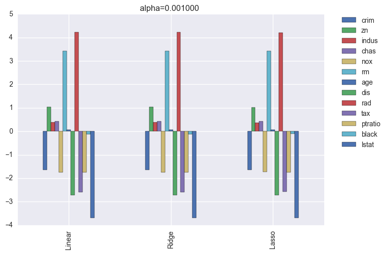

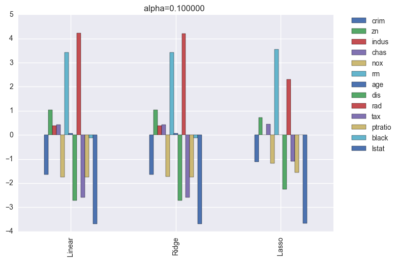

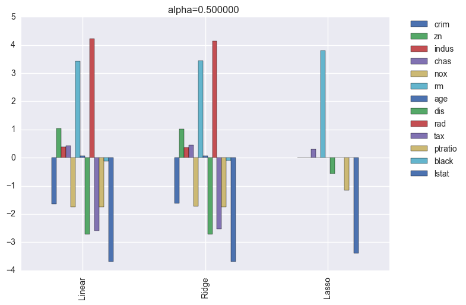

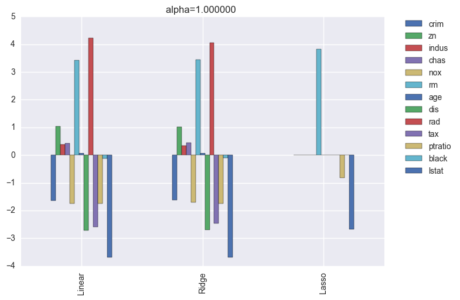

```python
def plot_result(alpha):
    linear=lm.LinearRegression()
    lasso = lm.Lasso(alpha=alpha)
    ridge = lm.Ridge(alpha=alpha)

    linear.fit(X_tr,y_tr)
    ridge.fit(X_tr,y_tr)
    lasso.fit(X_tr,y_tr)

    result_coef = pd.DataFrame([linear.coef_,ridge.coef_,lasso.coef_],index = ["Linear","Ridge","Lasso"],
                               columns=list(df.columns.values)[0:13])
    result_coef.plot.bar()
    plt.hold(True)
    plt.legend(bbox_to_anchor=(1.05, 1), loc='upper left', borderaxespad=0)
    plt.title("alpha=%f " % alpha)

plot_result(0.001)
plot_result(0.1)
plot_result(0.5)
plot_result(1.0)
```

## テストデータを用いた実験

lassoについては$\alpha$によって係数が鋭敏に変化していることがわかった。そこで訓練データより推定した係数$\boldsymbol{\beta}$を用いて、テストデータをどのていど予測できているかをみる。その際、$\alpha$を変化させたときテストデータについての平均誤差にどのように影響を及ぼすかをみる。

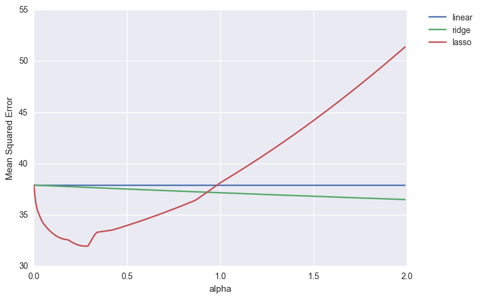

```python
alpha=np.arange(10E-10,2.0,0.01)

lin_E=[]
ridge_E=[]
lasso_E=[]

for a in alpha:
    linear=lm.LinearRegression()
    ridge = lm.Ridge(alpha=a)
    lasso = lm.Lasso(alpha=a)

    linear.fit(X_tr,y_tr)
    lasso.fit(X_tr,y_tr)
    ridge.fit(X_tr,y_tr)

    lin_error =0
    ridge_error=0
    lasso_error =0
    n_test=len(y_test)
    for i in range(n_test):
        lin_error += (y_test[i]-sum(X_test[i,]*linear.coef_)-linear.intercept_)**2/n_test
        ridge_error+=(y_test[i]-sum(X_test[i,]*ridge.coef_)-ridge.intercept_)**2/n_test
        lasso_error +=(y_test[i]-sum(X_test[i,]*lasso.coef_)-lasso.intercept_)**2/n_test
    lin_E.append(lin_error)
    ridge_E.append(ridge_error)
    lasso_E.append(lasso_error)

plt.hold(True);
plt.xlabel("alpha")
plt.ylabel("Mean Squared Error")
plt.plot(alpha,lin_E,label="linear")
plt.plot(alpha,ridge_E,label="ridge")
plt.plot(alpha,lasso_E,label="lasso")
plt.legend(bbox_to_anchor=(1.05, 1), loc='upper left', borderaxespad=0)
plt.show()
```

もう少し$\alpha$の範囲を細かくしてみる。

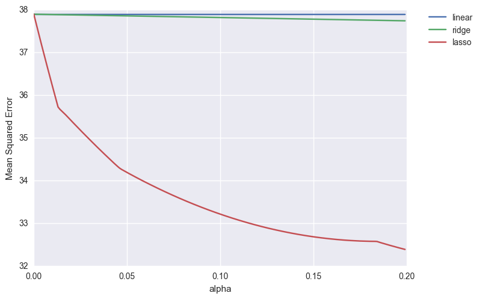

```python
alpha=np.arange(10E-10,0.2,10E-4)

lin_E=[]
ridge_E=[]
lasso_E=[]

for a in alpha:
    linear=lm.LinearRegression()
    ridge = lm.Ridge(alpha=a)
    lasso = lm.Lasso(alpha=a)

    linear.fit(X_tr,y_tr)
    lasso.fit(X_tr,y_tr)
    ridge.fit(X_tr,y_tr)

    lin_error =0
    ridge_error=0
    lasso_error =0
    n_test=len(y_test)
    for i in range(n_test):
        lin_error += (y_test[i]-sum(X_test[i,]*linear.coef_)-linear.intercept_)**2/n_test
        ridge_error+=(y_test[i]-sum(X_test[i,]*ridge.coef_)-ridge.intercept_)**2/n_test
        lasso_error +=(y_test[i]-sum(X_test[i,]*lasso.coef_)-lasso.intercept_)**2/n_test
    lin_E.append(lin_error)
    ridge_E.append(ridge_error)
    lasso_E.append(lasso_error)

plt.hold(True);
plt.xlabel("alpha")
plt.ylabel("Mean Squared Error")
plt.plot(alpha,lin_E,label="linear")
plt.plot(alpha,ridge_E,label="ridge")
plt.plot(alpha,lasso_E,label="lasso")
plt.legend(bbox_to_anchor=(1.05, 1), loc='upper left', borderaxespad=0)
plt.show()
```

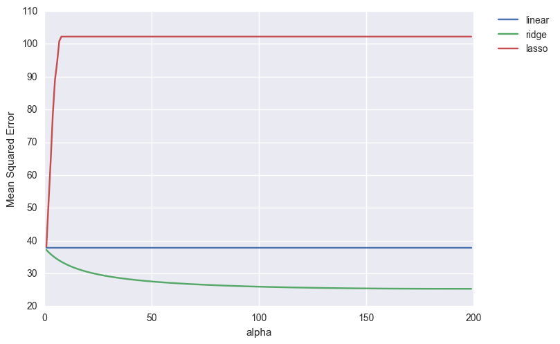

```python
alpha=np.arange(1,200,1)

lin_E=[]
ridge_E=[]
lasso_E=[]

for a in alpha:
    linear=lm.LinearRegression()
    ridge = lm.Ridge(alpha=a)
    lasso = lm.Lasso(alpha=a)

    linear.fit(X_tr,y_tr)
    lasso.fit(X_tr,y_tr)
    ridge.fit(X_tr,y_tr)

    lin_error =0
    ridge_error=0
    lasso_error =0
    n_test=len(y_test)
    for i in range(n_test):
        lin_error += (y_test[i]-sum(X_test[i,]*linear.coef_)-linear.intercept_)**2/n_test
        ridge_error+=(y_test[i]-sum(X_test[i,]*ridge.coef_)-ridge.intercept_)**2/n_test
        lasso_error +=(y_test[i]-sum(X_test[i,]*lasso.coef_)-lasso.intercept_)**2/n_test
    lin_E.append(lin_error)
    ridge_E.append(ridge_error)
    lasso_E.append(lasso_error)

plt.hold(True)
plt.xlabel("alpha")
plt.ylabel("Mean Squared Error")
plt.plot(alpha,lin_E,label="linear")
plt.plot(alpha,ridge_E,label="ridge")
plt.plot(alpha,lasso_E,label="lasso")
plt.legend(bbox_to_anchor=(1.05, 1), loc='upper left', borderaxespad=0)
plt.hold(False)
plt.show()
```

## 考察

平均2乗誤差について、平滑化パラメータ$\alpha$に依存した変化がみられた。